# CFRM 502, Winter 2020

# Instructor: Bahman Angoshtari

# Lecture 1

**Lecture 1:** R preliminaries; obtaining financial data; calculating asset returns, principles of financial data science

$\newcommand{\eps}{\varepsilon}$ $\newcommand{\Var}{\operatorname{Var}}$ $\newcommand\Cov{\operatorname{Cov}}$ $\newcommand{\sig}{\sigma}$ $\newcommand{\al}{\alpha}$ $\newcommand{\Xb}{\bar{X}}$ $\newcommand{\Yb}{\bar{Y}}$ $\newcommand\Eb{\mathbb{E}}$ $\newcommand\Pb{\mathbb{P}}$ $\newcommand\Qb{\mathbb{Q}}$ $\newcommand\Rb{\mathbb{R}}$ $\newcommand\Zb{\mathbb{Z}}$ $\newcommand\Nb{\mathbb{N}}$ $\newcommand\Av{\textbf{A}}$ $\newcommand\Fv{\textbf{F}}$ $\newcommand\Gv{\textbf{G}}$ $\newcommand\Hv{\textbf{H}}$ $\newcommand\Kv{\textbf{K}}$ $\newcommand\Iv{\textbf{I}}$ $\newcommand\Pv{\textbf{P}}$ $\newcommand\Sv{\textbf{S}}$ $\newcommand\Xv{\textbf{X}}$ $\newcommand\Yv{\textbf{Y}}$ $\newcommand\Zv{\textbf{Z}}$ $\newcommand\av{\mathbf{a}}$ $\newcommand\xv{\mathbf{x}}$ $\newcommand\yv{\mathbf{y}}$ $\newcommand\zv{\mathbf{z}}$ $\newcommand\Cv{\mathbf{C}}$ $\newcommand\mv{\mathbf{m}}$ $\newcommand\nv{\mathbf{n}}$ $\newcommand\pv{\mathbf{p}}$ $\newcommand\sv{\mathbf{s}}$ $\newcommand\wv{\mathbf{w}}$ $\newcommand\Wv{\textbf{W}}$ $\newcommand\betav{{\boldsymbol\beta}}$ $\newcommand\etav{{\boldsymbol\eta}}$ $\newcommand\epsv{{\boldsymbol\varepsilon}}$ $\newcommand\delv{{\boldsymbol\delta}}$ $\newcommand\Lamv{{\boldsymbol\Lambda}}$ $\newcommand\lamv{{\boldsymbol\lambda}}$ $\newcommand\muv{{\boldsymbol\mu}}$ $\newcommand\piv{{\boldsymbol\pi}}$ $\newcommand\Pbh{\widehat{\Pb}}$ $\newcommand\Ebh{\widehat{\Eb}}$ $\newcommand\Qh{\widehat{Q}}$ $\newcommand\Ih{\widehat{I}}$ $\newcommand\pih{\widehat{\pi}}$ $\newcommand\Pih{\widehat{\Pi}}$ $\newcommand\Wh{\widehat{W}}$ $\newcommand\Fh{\widehat{F}}$ $\newcommand\Yh{\widehat{Y}}$ $\newcommand\Yvh{\widehat{\Yv}}$ $\newcommand\Ah{\widehat{\Ac}}$ $\newcommand\uh{\widehat{u}}$ $\newcommand\vh{\widehat{v}}$ $\newcommand\fh{\widehat{f}}$ $\newcommand\hh{\widehat{h}}$ $\newcommand\Bh{\widehat{B}}$ $\newcommand\rhoh{\widehat{\rho}}$ $\newcommand\nuh{\widehat{\nu}}$ $\newcommand\varphih{\widehat{\varphi}}$ $\newcommand\thetah{\widehat{\theta}}$ $\newcommand\betah{\widehat{\beta}}$ $\newcommand\betavh{\widehat{\boldsymbol\beta}}$ $\newcommand\kaph{\widehat{\kappa}}$ $\newcommand\sigh{\widehat{\sigma}}$ $\newcommand\epsh{\widehat{\eps}}$ $\newcommand\epsvh{\widehat{\epsv}}$ $\newcommand\Pt{\tilde{P}}$

# 0. Overview of the lecture

- We first go over the course organization (see the syllabus).
- We then briefly go over R and how to get financial data. We also show how to calculate stock returns.
- In the last part of the lecture, we overview a few general considerations in financial data analysis.

```r
# Setting parameters of the Jupyter notebook
# This cell is only usefull if your are using Jupyter
sc = 1.2
options(repr.plot.width=16*sc,
        repr.plot.height=6*sc,
        repr.plot.pointsize = 20, # Text height in pt
        repr.plot.bg        = 'white',
        repr.plot.antialias = 'gray',
        #nice medium-res DPI
        repr.plot.res       = 300,
        #jpeg quality bumped from default
        repr.plot.quality   = 90,
        #vector font family
        repr.plot.family    = 'serif') # Vector font family. 'sans', 'serif', 'mono' or a specific one
```

# 1. Obtaining financial data

- R is a programming language for statistical computing and graphics. It is widely used among statisticians and contains a large number of ready-to-use functions (called *packages*).
- Start by installing R. Please visit: https://www.r-project.org/.
- This will install the R software. It is also recommended to install an IDE (integrated development environment) for R, such as RStudio. Please visit: https://www.rstudio.com/products/rstudio/download/.
- Alternatively, you may use [Jupyter](https://jupyter.org/) (this is the software used for creating the lecture notes and slides)
- There are many online resources for learning R. I will briefly explain the codes presented in each class. However, you should thoroughly examine each code on your own, and use the R documentation to learn how they are used.
- Let us open RStudio, and install our first package. As mentioned before, packages include ready-to-use functions. `quantmod` is a package that can be used for obtaining financial data.
- To install the package use Tools -> Install Packages... menu in RStudio, or directly use the following command:

```r
install.packages("quantmod")
```

- This command copy the package files on our computer (from an online repository). You only need to install a package once.
- However, to be able to use an installed package, we need to load it. This is done by the following command.

```r
library('quantmod')
```

- As you can see, R automatically load other packages that `quantmod` relies on, namely, packages `xtx` and `zoo` (both are packages that define time-series data types).
- `quantmod` provides the function `getSymbols()` which can be used to find historical financial and economical data from various online resources.
- Let us load historical data from Apple Inc. from Yahoo! finance. First, we need to find the symbol for Apple. Searching the web, we find the symbol at https://finance.yahoo.com/quote/AAPL/.
- Thus, the symbol is `AAPL`. Now, we can use the following R command to obtain the data.

```r
getSymbols("AAPL", from="2007-01-01", to="2018-9-30",
           src="yahoo", auto.assign=TRUE)
```

[output not shown]

'AAPL'

- We have obtained the historical data of symbol `AAPL`, from January 2007 until September 2018, using the data source `yahoo` (Yahoo! finance), and store it as a variable called `AAPL`.
- To see the type of `AAPL`, we write:

```r
class(AAPL)
```

1. 'xts'

2. 'zoo'

- The variable is an extended time series (xts) object, which is a subclass of type `zoo`. These are essentially 2 dimensional arrays, where the index rows are date/time objects.
- To get the total number of rows and columns, we can use:

```r
dim(AAPL)
```

1. 2957

2. 6

```r
names(AAPL)
```

1. 'AAPL.Open'

2. 'AAPL.High'

3. 'AAPL.Low'

4. 'AAPL.Close'

5. 'AAPL.Volume'

6. 'AAPL.Adjusted'

- The columns are open price (the first trade of the day), high price (the highest price of the day), low price (the lowest price of the day), close price (the last trade of the day), volume (the total number of shares traded during the day), and the adjusted prices (the price that is adjusted to include the effect of corporate events such as dividend payments and stock splits, more on this later).
- To get the first few rows of the xts object, we can use the function `head()`, and to get the last few rows, we can use the function `tail()`.

```r
head(AAPL)
```

```
           AAPL.Open AAPL.High AAPL.Low AAPL.Close AAPL.Volume AAPL.Adjusted
2007-01-03  12.32714  12.36857 11.70000   11.97143   309579900      10.41635
2007-01-04  12.00714  12.27857 11.97429   12.23714   211815100      10.64755
2007-01-05  12.25286  12.31428 12.05714   12.15000   208685400      10.57173
2007-01-08  12.28000  12.36143 12.18286   12.21000   199276700      10.62393
2007-01-09  12.35000  13.28286 12.16429   13.22429   837324600      11.50647
2007-01-10  13.53571  13.97143 13.35000   13.85714   738220000      12.05711
```

```r
tail(AAPL)
```

```
           AAPL.Open AAPL.High AAPL.Low AAPL.Close AAPL.Volume AAPL.Adjusted
2018-09-21    220.78    221.36   217.29     217.66    96246700      213.6925
2018-09-24    216.82    221.26   216.63     220.79    27693400      216.7654
2018-09-25    219.75    222.82   219.70     222.19    24554400      218.1399
2018-09-26    221.00    223.75   219.76     220.42    23984700      216.4021
2018-09-27    223.82    226.44   223.54     224.95    30181200      220.8496
2018-09-28    224.79    225.84   224.02     225.74    22929400      221.6252
```

- To choose a specific date range, we can use

```r
AAPL["2015-12-23/2015-12-31"]
```

```
           AAPL.Open AAPL.High AAPL.Low AAPL.Close AAPL.Volume AAPL.Adjusted
2015-12-23    107.27    108.85   107.20     108.61    32657400     101.49305
2015-12-24    109.00    109.00   107.95     108.03    13570400     100.95106
2015-12-28    107.59    107.69   106.18     106.82    26704200      99.82036
2015-12-29    106.96    109.43   106.86     108.74    30931200     101.61453
2015-12-30    108.58    108.70   107.18     107.32    25213800     100.28758
2015-12-31    107.01    107.03   104.82     105.26    40912300      98.36257
```

or

```r
AAPL["2015-12"]
```

```
           AAPL.Open AAPL.High AAPL.Low AAPL.Close AAPL.Volume AAPL.Adjusted
2015-12-01    118.75    118.81   116.86     117.34    34852400     109.65099
2015-12-02    117.34    118.11   116.08     116.28    33386600     108.66045
2015-12-03    116.55    116.79   114.22     115.20    41569500     107.65123
2015-12-04    115.29    119.25   115.11     119.03    57777000     111.23026
2015-12-07    118.98    119.86   117.81     118.28    32084200     110.52941
2015-12-08    117.52    118.60   116.86     118.23    34309500     110.48266
2015-12-09    117.64    117.69   115.08     115.62    46361400     108.04370
2015-12-10    116.04    116.94   115.51     116.17    29212700     108.55766
2015-12-11    115.19    115.39   112.85     113.18    46886200     105.76359
2015-12-14    112.18    112.68   109.79     112.48    64318700     105.10945
2015-12-15    111.94    112.80   110.35     110.49    53323100     103.24987
2015-12-16    111.07    111.99   108.80     111.34    56238500     104.04415
2015-12-17    112.02    112.25   108.98     108.98    44772800     101.83881
2015-12-18    108.91    109.52   105.81     106.03    96453300      99.08212
2015-12-21    107.28    107.37   105.57     107.33    47590600     100.29692
2015-12-22    107.40    107.72   106.45     107.23    32789400     100.20349
2015-12-23    107.27    108.85   107.20     108.61    32657400     101.49305
2015-12-24    109.00    109.00   107.95     108.03    13570400     100.95106
2015-12-28    107.59    107.69   106.18     106.82    26704200      99.82036
2015-12-29    106.96    109.43   106.86     108.74    30931200     101.61453
2015-12-30    108.58    108.70   107.18     107.32    25213800     100.28758
2015-12-31    107.01    107.03   104.82     105.26    40912300      98.36257
```

- Finally, we can obtain a quick financial chart of the data using the function `chartSeries()`

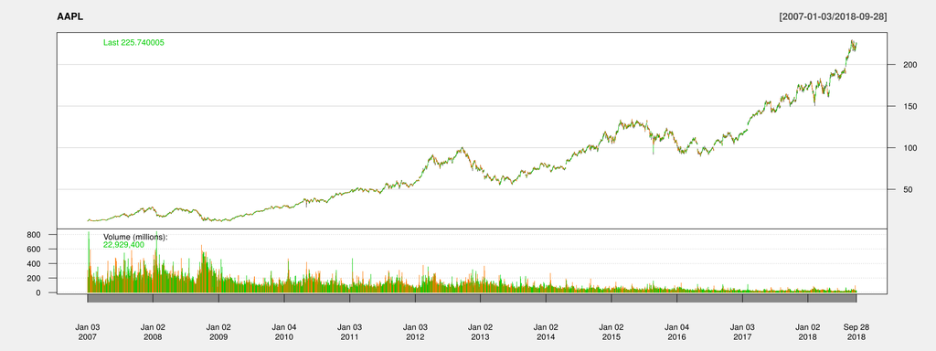

```r
chartSeries(AAPL, theme="white")
```

- We can also plot a specific range, as follows:

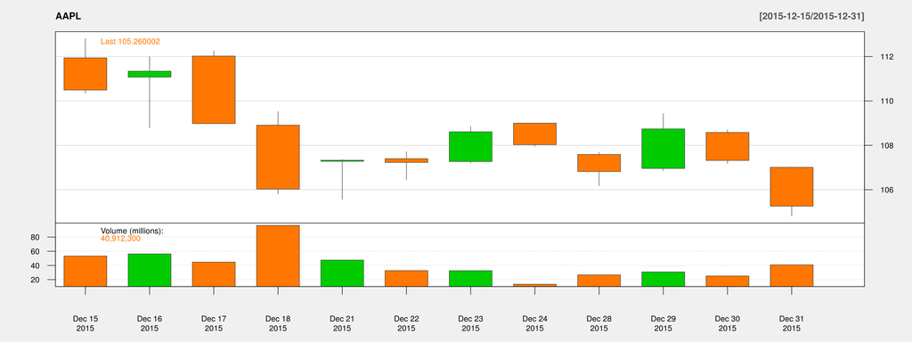

```r
chartSeries(AAPL, theme="white", subset="2015-12-15::2015-12-31")
```

- We can use other sources to obtain data. For example, let us obtain monthly unemployment rate from Federal Reserve Economic Data (FRED). We may find the symbol for unemployment rate in the following page https://fred.stlouisfed.org/series/UNRATE, which reveals that the symbol is `UNRATE`. We can then obtain and chart the data, as follows:

```r
getSymbols("UNRATE",src="FRED")
dim(UNRATE)
head(UNRATE)
tail(UNRATE)
```

'UNRATE'

1. 863

2. 1

```
           UNRATE
1948-01-01    3.4
1948-02-01    3.8
1948-03-01    4.0
1948-04-01    3.9
1948-05-01    3.5
1948-06-01    3.6
```

```
           UNRATE
2019-06-01    3.7
2019-07-01    3.7
2019-08-01    3.7
2019-09-01    3.5
2019-10-01    3.6
2019-11-01    3.5
```

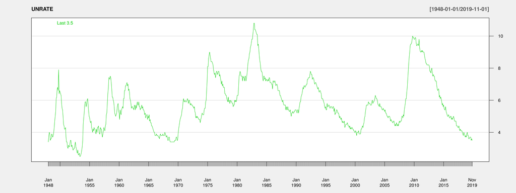

```r
chartSeries(UNRATE, theme="white")
```

# 2. Asset Returns

- Let $P_0$, $P_1$, ... be the price of an equity
- Assume no "corporate actions" such as dividends, split, etc.
- **Net return over $[t-1,t]$:**

\begin{align*} R_t:= \frac{P_t-P_{t-1}}{P_{t-1}} \end{align*}

- Since $P_{t-1}>0$, we have $R_t>-1$. The worst case happens if the asset loses all of its value.
- **Gross return over $[t-1,t]$:** $\displaystyle 1+R_t:= \frac{P_t}{P_{t-1}}$.

**Multi period returns:**

- Gross return over $[t-k,t]$:

\begin{align*} 1+R_t(k):= \frac{P_t}{P_{t-k}} = (1+R_t)(1+R_{t-1})\dots(1+R_{t-k+1}) \end{align*}

- $R_t(k)$ is the net return of $[t-k,t]$

**Log returns:**

- Log returns over $[t-1,t]$:

\begin{align*} r_t:= \log(1+R_t) = \log\frac{P_t}{P_{t-1}} \end{align*}

- Log returns over $[t-k,t]$:

\begin{align*} r_t(k):= \log\frac{P_t}{P_{t-k}} = r_t + r_{t-1} + \dots + r_{t-k+1} \end{align*}

**Example**

The following table gives two daily (adjusted) closing price of Apple stock in Dec. 2015

| Date | 12/23 | 12/24 |
| --- | --- | --- |
| Price(\$) | 104.56 | 104.00 |

- Gross (daily) return on 12/24 is

\begin{align*} \frac{104}{104.56}=0.994644 \end{align*}

- Log return on 12/24 is

\begin{align*} \log 104.00 - \log 104.56 =-0.005370 \end{align*}

- For small $|x|$, we have $x\approx \log(1+x)$. Practically, log and net returns are interchangeable.

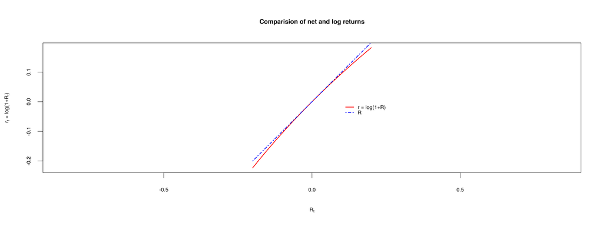

```r
R <- seq(-0.2, 0.2, len=100)
r <- log(1+R)
plot(x=R, y=r, xlab = expression("R"["t"]),
     ylab = expression("r"["t"]*" = log(1+R"["t"]*")"),
     lwd=2, type = "l", col=2, asp = 1)
lines(x=R, y=R, col=4, lty=4, lwd=2)
title(main= "Comparision of net and log returns")
legend(x=0.1, y=0, c("r = log(1+R)","R"),
       col=c(2, 4), lty = c(1, 4), lwd=2,
       bty = "n")
```

- Q: Suppose that we use log returns instead of net returns. Are we over-estimating or under-estimating losses? How about gains?
- A: Underestimating gains, overestimating losses.

## 2.1 Adjusted price

- There are many market events that makes our return formula inappropriate for quoted prices, e.g. dividend payments, stock splits, etc.
- Let $D_1$, $D_2$, ... be the dividends of a stock with quoted prices $P_1$, $P_2$, ... . Here, $D_t$ is the dividend paid at $t$.
- Then, the appropriate definition of the net return should be

  $\displaystyle R_t = \frac{P_t + D_t - P_{t-1}}{P_{t-1}}$

  and the multi-period net return $R_t(k)$ should be

  $1+ R_t(k) = (1+R_t)(1+R_{t-1}) \dots (1+R_{t-k+1})$

  $= \left(\frac{P_t+D_t}{P_{t-1}}\right)\left(\frac{P_{t-1}+D_{t-1}}{P_{t-2}}\right)\dots\left(\frac{P_{t-k+1}+D_{t-k+1}}{P_{t-k}}\right) \ne \frac{P_t}{P_{t-k}}$
- **The idea behind "adjusted prices":** Find prices $\Pt_1, \tilde{P}_2,\ldots$, such that return are given by "simple" formulas applied to $\Pt$. In other words

  $1+R_t= \frac{\Pt_t}{\tilde{P}_{t-1}}\quad\Longrightarrow\quad \frac{P_t + D_t}{P_{t-1}} = \frac{\Pt_t}{\Pt_{t-1}} \quad\Longrightarrow\quad \Pt_t = \left(\frac{P_t+D_t}{P_{t-1}}\right) \Pt_{t-1}$
- Thus, by recursively defining $\Pt_1$, $\Pt_2$, ... as follows

  $\begin{cases}\Pt_0 = P_0\\\displaystyle\Pt_t = \left(\frac{P_t+D_t}{P_{t-1}}\right) \Pt_{t-1}\end{cases}$

  we may use the formula

  $\displaystyle R_t = \frac{\Pt_{t}-\Pt_{t-1}}{\Pt_{t-1}}$

  Other returns formulas will also be in the simple (i.e. assuming no dividend) form.
- There are many such adjustment for different types of events. Always use "adjust prices" to calculate returns.
- Next, we show two ways to calculate asset returns using R. Let us first obtain the prices of Apple Inc.

```r
getSymbols("AAPL", from="2017-10-03", to="2017-10-13", src="yahoo")
names(AAPL)
```

'AAPL'

1. 'AAPL.Open'

2. 'AAPL.High'

3. 'AAPL.Low'

4. 'AAPL.Close'

5. 'AAPL.Volume'

6. 'AAPL.Adjusted'

- As mentioned before, the adjusted price is the column `AAPL.Adjusted`. We can obtain the column by using the `$` operator:

```r
AAPL$AAPL.Adjusted
```

```
           AAPL.Adjusted
2017-10-03      149.4051
2017-10-04      148.4380
2017-10-05      150.2852
2017-10-06      150.1981
2017-10-09      150.7204
2017-10-10      150.7784
2017-10-11      151.4071
2017-10-12      150.8752
```

- In our first method, we convert the adjusted prices from `xts` objects to vectors, and then calculate the returns. This is the approach taken by the textbook. Note the use of negative index in R. If `X` is a vector, then `X[-n]` is the vector `X` with its n-th element removed.

```r
Pvec = as.vector(AAPL$AAPL.Adjusted)
Rvec <- Pvec[-1] / Pvec[-length(Pvec)] - 1
Rvec
rvec <- diff(log(Pvec))
rvec
class(rvec)
```

1. -0.00647332628645225

2. 0.0124443506559149

3. -0.000579145625890343

4. 0.0034771603522239

5. 0.000385010925992857

6. 0.0041695421056489

7. -0.00351328296986653

1. -0.00649436912364898

2. 0.0123675561729275

3. -0.000579313395496328

4. 0.00347112900742452

5. 0.000384936828304205

6. 0.00416087365226403

7. -0.00351946904167644

'numeric'

- A more direct approach, is to use the `lag()` and `diff()` functions (take a look at the R documentation to learn what they do).

```r
P <- AAPL$AAPL.Adjusted
R <- diff(P)/lag(P)
R
r <- diff(log(P))
r
class(r)
```

```
           AAPL.Adjusted
2017-10-03            NA
2017-10-04 -0.0064733263
2017-10-05  0.0124443507
2017-10-06 -0.0005791456
2017-10-09  0.0034771604
2017-10-10  0.0003850109
2017-10-11  0.0041695421
2017-10-12 -0.0035132830
```

```
           AAPL.Adjusted
2017-10-03            NA
2017-10-04 -0.0064943691
2017-10-05  0.0123675562
2017-10-06 -0.0005793134
2017-10-09  0.0034711290
2017-10-10  0.0003849368
2017-10-11  0.0041608737
2017-10-12 -0.0035194690
```

1. 'xts'

2. 'zoo'

Let us calculate the net and log returns for a longer period and plot the result.

```r
getSymbols("AAPL", from="2007-01-03", to="2017-10-13", src="yahoo")
names(AAPL)
AAPL.rtn = diff(AAPL$AAPL.Adjusted)/lag(AAPL$AAPL.Adjusted) # Compute net returns
colnames(AAPL.rtn)[1] = "net"
AAPL.rtn$log = diff(log(AAPL$AAPL.Adjusted)) # Compute log returns
head(AAPL.rtn)
```

'AAPL'

1. 'AAPL.Open'

2. 'AAPL.High'

3. 'AAPL.Low'

4. 'AAPL.Close'

5. 'AAPL.Volume'

6. 'AAPL.Adjusted'

```
                    net          log
2007-01-03           NA           NA
2007-01-04  0.022195486  0.021952752
2007-01-05 -0.007121076 -0.007146552
2007-01-08  0.004938550  0.004926396
2007-01-09  0.083070068  0.079799664
2007-01-10  0.047855527  0.046745721
```

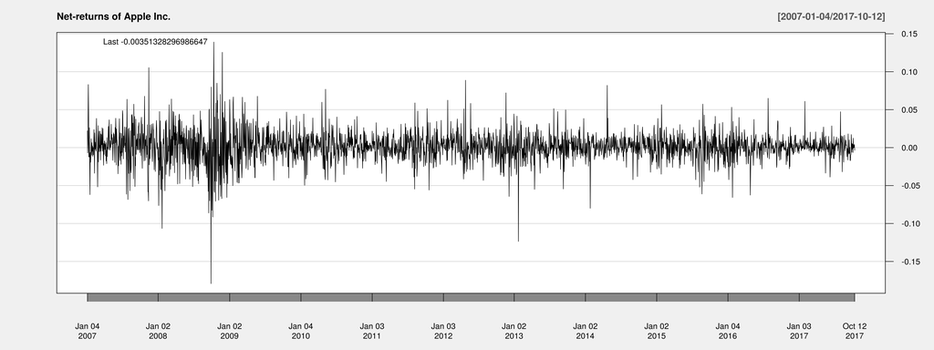

```r
chartSeries(AAPL.rtn$net, name = "Net-returns of Apple Inc.", theme=chartTheme("white", up.col='black'))
```

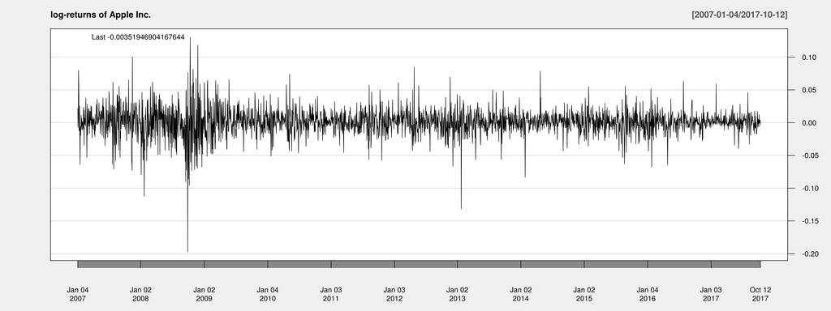

```r
chartSeries(AAPL.rtn$log, name = "log-returns of Apple Inc.", theme=chartTheme("white", up.col='black'))
```

# 3. Principles of financial data science

## 3.1 There is no "true model"

George Box quote:

> All models are wrong but some are useful.

## 3.2 Visualize the data first

- Every data analysis starts with an "exploratory data analysis."
- This step helps get a general idea of how the data looks like, and can help detect errors and anomalies in the data before a more substantial analysis is applied.
- Here, we describe three useful graphs: Histogram, KDE, and QQ plot. For more details of exploratory data analysis, read Chapter 4 of the textbook.

### 3.2.1 Histograms and kernel density estimators (KDE)

- Histograms and kernel density estimators (KDE) are used for estimating the distribution of a sample of identically distributed data.

  **Definition:** We say random variables $\{X_1, X_2, \dots, X_n\}$ are identically distributed if they have the same probability distribution.
- Let $X_1, X_2, \ldots, X_n$ be identically distributed. Then, by the law of large numbers (LLN), for constants $a$ and $b$,

  $\newcommand{\E}{\mathbb{E}\thinspace }$ $\newcommand\PP {\mathbb P}$ $\newcommand\1 {\mathbf 1}$ $\PP(a< X_t\le b) = \E(\1_{\{a<X_t\le b\}}) \overset{\text{LLN}}{\approx} \frac{\sum_{i=1}^n \1_{\{a<X_i\le b\}}}{n}.$

  In general, for any set $A$ of real numbers

  $\PP(X_t\in A) \overset{\text{LLN}}{\approx} \text{ proportion of observations that fall in A}.$

  Histograms are a way to summarize this information.
- Let us find a histogram of the past log returns of the S&P500 index (symbol `^GSPC`). First, we obtain the prices, and calculate the log returns.

'^GSPC'

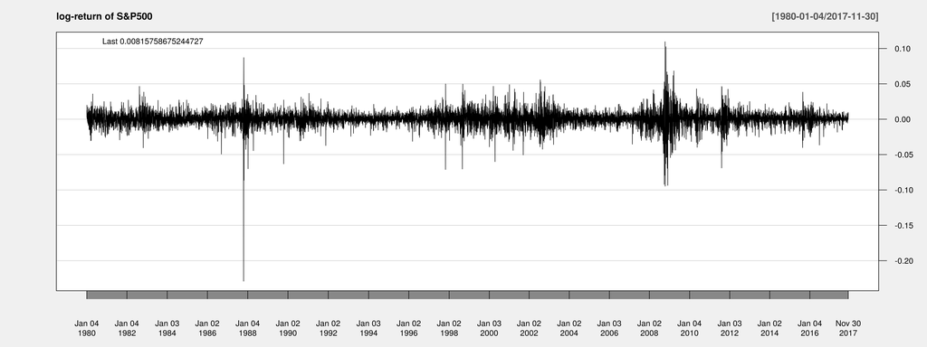

```r
library('quantmod')
getSymbols("^GSPC", from="1980-01-03", to="2017-12-01", src="yahoo")
GSPC.rtn=diff(log(GSPC$GSPC.Adjusted)) # Compute log returns
chartSeries(GSPC.rtn, name="log-return of S&P500",
            type = "line", theme=chartTheme("white", up.col='black'))
```

- Next, we assume that the returns are identically distributed. To find the common distribution, we plot their histograms.
- To obtain the histogram, we divide the data range into sub-intervals. Each sub-interval is called a "bin". We then specify the number of observations in each bin (frequency), or the "probability density" of each bin such that the total area under the histogram is 1. We also need to make a choice about the number (or size) of bins.

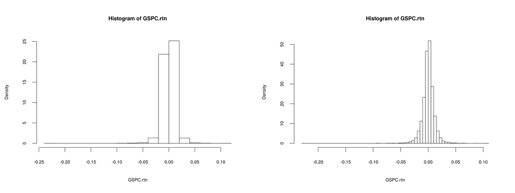

```r
par(mfrow=c(1,2))
hist(GSPC.rtn, freq=FALSE, breaks = 20)   # bins are too large
hist(GSPC.rtn, freq=FALSE, breaks = 50)
```

- The idea of histograms is extended to the "Kernel Density estimator" (KDE).
- Let $X_1, X_2, \ldots, X_n$ be identically distributed.
- Let $k(x)$ be a "kernel function," that is, a function satisfying the following conditions
  - $k(x) = k(-x)$
  - $k(x)\ge0$
  - $\newcommand\dd{\mathrm{d}}$$\int_{-\infty}^{\infty}k(x)\dd x=1$
- Then, the KDE of the marginal density of $X$, using kernel $k$, is

  $\hat{f}(x) = \frac{1}{n\,b}\sum_{i=1}^n k\left(\frac{x-X_i}{b}\right).$

  Here, $b>0$ is a constant called the "bandwidth" of the KDE.
- $\newcommand\Rb {\mathbb R}$ The factor $\frac{1}{nb}$ guarantees that $\int_\Rb \hat{f}(x)\dd x = 1$.
- Let us illustrate KDE
- We start by creating a dataset

```r
set.seed("992291")
x = rnorm(6)
l = matrix(1,200,6)
l2 = l
l3 =l
xgrid = seq(from=-3,to=1.5,length=200)
for (i in 1:6)
{
  l[,i] = dnorm(xgrid,x[i],.4)/6
  l2[,i] = dnorm(xgrid,x[i],.2)/6
  l3[,i] = dnorm(xgrid,x[i],.8)/6

}
kde = l%*%matrix(1,6,1)
kde2 = l2%*%matrix(1,6,1)
kde3 = l2%*%matrix(1,6,1)
```

```r
# Setting parameters of the Jupyter notebook
# This cell is only usefull if your are using Jupyter
sc = 1.2
options(repr.plot.width=16*sc,
        repr.plot.height=6*sc,
        repr.plot.pointsize = 20, # Text height in pt
        repr.plot.bg        = 'white',
        repr.plot.antialias = 'gray',
        #nice medium-res DPI
        repr.plot.res       = 300,
        #jpeg quality bumped from default
        repr.plot.quality   = 90,
        #vector font family
        repr.plot.family    = 'serif') # Vector font family. 'sans', 'serif', 'mono' or a specific one
```

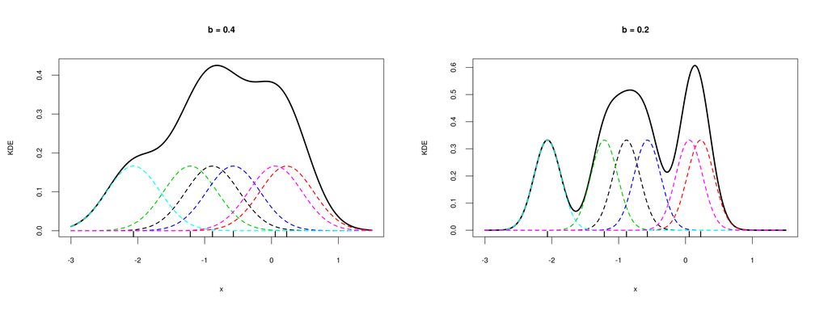

```r
par(mfrow=c(1,2))
plot(xgrid,kde,type="l",lwd=3,xlab="x", font.lab=1, ylab="KDE",main="b = 0.4")
for (i in 1:6){lines(xgrid,l[,i],lwd=2,lty=2,col=i)}
rug(x,side=1,lwd=2)
plot(xgrid,kde2,type="l",lwd=3,xlab="x",ylab="KDE",main="b = 0.2")
for (i in 1:6){lines(xgrid,l2[,i],lwd=2,lty=2,col=i)}
rug(x,side=1,lwd=2)
```

- Small values of the bandwidth result in high variance for KDE (it will be non-smooth). Large value of the bandwidth result in smooth KDE, but introduce bias. R can automatically determine a good choice for the bandwidth parameter.

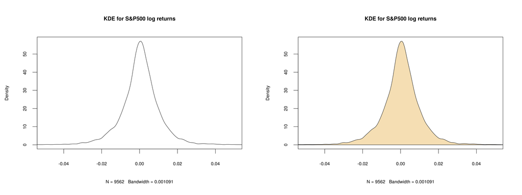

```r
par(mfrow=c(1,2))
d <- density(GSPC.rtn, adjust = 1, na.rm = TRUE)
plot(d, xlim=c(-0.05,0.05),
     main="KDE for S&P500 log returns") # simple plot
plot(d, type = "n", xlim=c(-0.05,0.05),
     main="KDE for S&P500 log returns") # more sophisticated plot
polygon(d, col = "wheat")
```

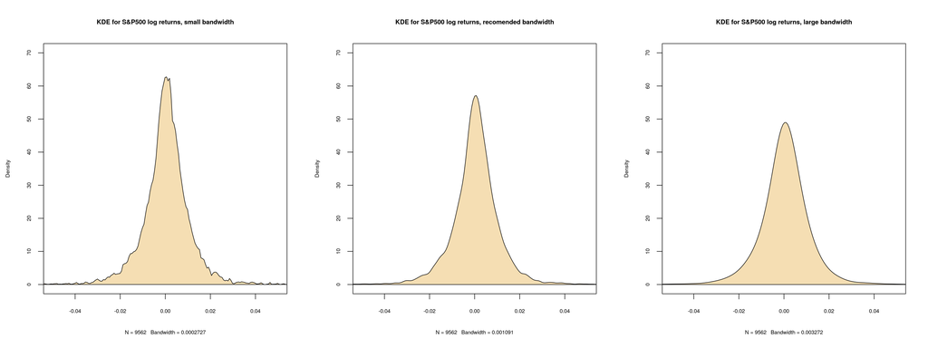

```r
par(mfrow=c(1,3))
d <- density(GSPC.rtn, adjust = 0.25, na.rm = TRUE) # Small bandwidth, higher variance
plot(d, type = "n", xlim=c(-0.05,0.05), ylim=c(0, 70),
     main="KDE for S&P500 log returns, small bandwidth")
polygon(d, col = "wheat")

d <- density(GSPC.rtn, adjust = 1, na.rm = TRUE) # Default bandwidth
plot(d, type = "n", xlim=c(-0.05,0.05), ylim=c(0, 70),
     main="KDE for S&P500 log returns, recomended bandwidth")
polygon(d, col = "wheat")

d <- density(GSPC.rtn, adjust = 3, na.rm = TRUE) # Large bandwidth, higher bias
plot(d, type = "n", xlim=c(-0.05,0.05), ylim=c(0, 70),
     main="KDE for S&P500 log returns, large bandwidth")
polygon(d, col = "wheat")
```

### 3.2.2 QQ plots

- QQ plots help in comparing the distribution of a sample with a known distribution or another sample

  **Definition:** The $q$-th quantile (or $100q$-th percentile) of a sample $X_1, X_2, \dots, X_n$ is $X_{(\lceil n q \rceil)}$. Here, $\lceil x \rceil$ is the ceiling function ($\lceil x \rceil$ is the smallest integer that is larger that $x$), and $X_{(1)},X_{(2)}, \dots, X_{(n)}$ are the order statistics, that is, the sample ordered from smallest to largest.
- Idea of QQ plots: Let X and Y be two random variables such that $Y= a + b X$. $\newcommand{\al}{\alpha}$Let $q_\al$ and $\hat{q}_\al$ the the $\al$-th quantiles of X and Y, respectively. Then, one has $\hat{q}_\al = a + b q_\al$.
- A QQ plot is the plot of the quantiles of a sample against the quantiles of a known distribution or quantiles of another sample.
- If there is a linear relation between two random variables, their QQ plots should be almost linear.
- A very common QQ plot is the plot of quantile of a sample vs. the quantiles of the normal distribution. This is called a normal probability plot, and is used to determine if a sample is from a normal distribution. A plot that appear almost linear indicates normally distributed sample.
- Let us get a normal probability plot for the log-returns of S&P500. Do you think the returns are normal?

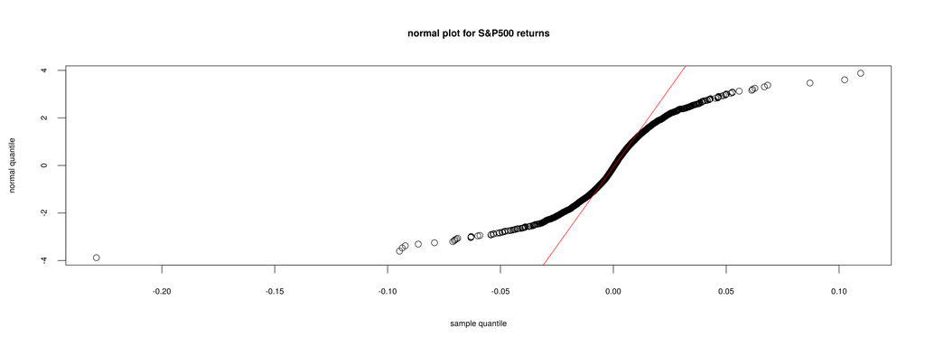

```r
qqnorm(as.vector(GSPC.rtn), datax = TRUE, main = "normal plot for S&P500 returns",
       xlab = "normal quantile", # this is for the theoretical quantiles
       ylab = "sample quantile") # this is for the sample quantiles
qqline(as.vector(GSPC.rtn), datax=TRUE, col = 2)
```

- The QQ plot indicates that the S&P500 returns are not normal. In particular, they have larger tail probabilities than a normal distribution with the same mean and variance.
- Pay special attention to the interpretation of QQ plots. See Figure 4.9 of page 55 of the textbook.

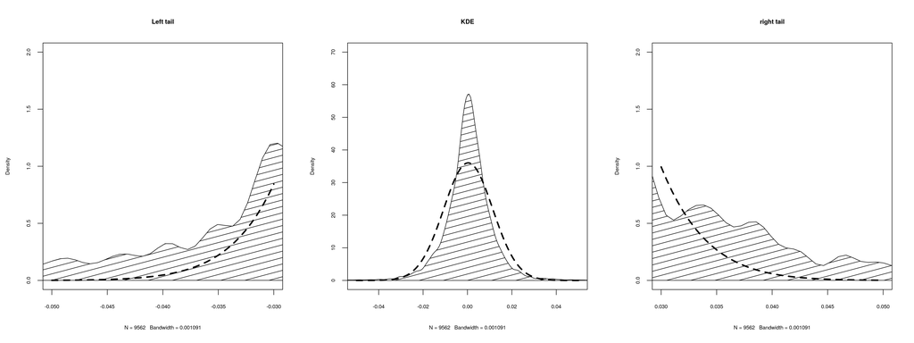

```r
par(mfrow=c(1,3))
mu=mean(GSPC.rtn, na.rm=TRUE)
sig=sd(GSPC.rtn, na.rm=TRUE)
xlims = list(c(-0.05,-0.03), c(-0.05,0.05), c(0.03,0.05))
ylims = list(c(0,2), c(0,70), c(0,2))
titles = list("Left tail", "KDE", "right tail")
for (i in 1:3){
    d <- density(GSPC.rtn, adjust = 1, na.rm = TRUE)
    plot(d, type = "n", xlim=xlims[[i]], ylim=ylims[[i]], main=titles[[i]])
    polygon(d, angle=45, density=10)
    zdist = seq(from=xlims[[i]][[1]],to=xlims[[i]][[2]],by=.0005)
    lines(zdist,dnorm(zdist, mean=mu, sd=sig), lty=2,lwd=3,col="black")
}
```

## 3.3 Bias-variance tradeoff

- Simple models tend to have low variability and high bias. Complex models are noisy (their output varies a lot) but are unbiased. The level of complexity should take this tradeoff into account.
- We will see many examples of the Bias-variance principle throughout the course. Let us examine it in the context of deciding on the bandwidth of a KDE.

```r
# Setting parameters of the Jupyter notebook
sc = 1
options(repr.plot.width=16*sc,
        repr.plot.height=6*sc,
        repr.plot.pointsize = 20, # Text height in pt
        repr.plot.bg        = 'white',
        repr.plot.antialias = 'gray',
        #nice medium-res DPI
        repr.plot.res       = 300,
        #jpeg quality bumped from default
        repr.plot.quality   = 90,
        #vector font family
        repr.plot.family    = 'serif') # Vector font family. 'sans', 'serif', 'mono' or a specific one
```

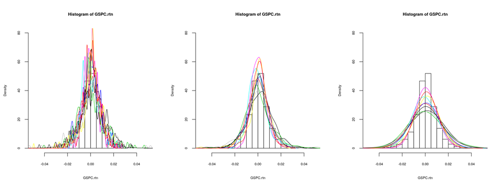

```r
par(mfrow=c(1,3))
adjustvalues = c(0.25, 1, 4)
for (i in 1:3){
    hist(GSPC.rtn, freq=FALSE, breaks = 50, xlim=c(-0.05,0.05), ylim = c(0,80))
    for (n in 1:10) {
      subsample = GSPC.rtn[(1+250*(n-1)):(250*n)]
      d <- density(subsample, adjust = adjustvalues[[i]], na.rm = TRUE)
      lines(d, lwd = 1, xlim = c(-0.1,0.1), col=n)
    }
}
```

## 3.4 Normal distribution is not normal

- Financial data tend to have more extreme values than what is allowed by Normal distribution.
- We have already seen this for the log-return of S&P500.
- One approach to address this issue, is to use "fat-tailed" distributions such as student-t distribution.

```r
# Setting parameters of the Jupyter notebook
sc = 1.25
options(repr.plot.width=6*sc,
        repr.plot.height=6*sc,
        repr.plot.pointsize = 20, # Text height in pt
        repr.plot.bg        = 'white',
        repr.plot.antialias = 'gray',
        #nice medium-res DPI
        repr.plot.res       = 70,
        #jpeg quality bumped from default
        repr.plot.quality   = 90,
        #vector font family
        repr.plot.family    = 'serif') # Vector font family. 'sans', 'serif', 'mono' or a specific one
```

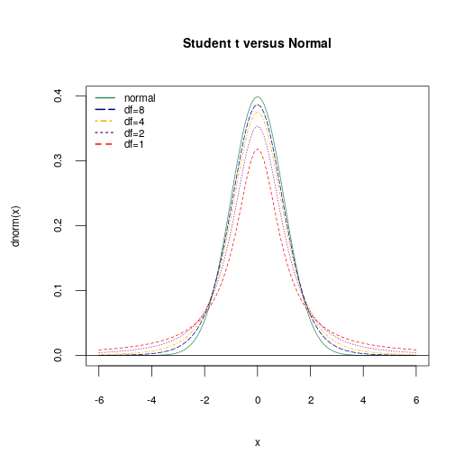

```r
curve(dnorm,-6,6,main="Student t versus Normal",col="seagreen",lwd=1)
curve(dt(x,df=1),add=T,col="red",lwd=1,lty="dashed")
curve(dt(x,df=2),add=T,col="darkmagenta",lwd=1,lty="dotted")
curve(dt(x,df=4),add=T,col="orange",lwd=1,lty="dotdash")
curve(dt(x,df=8),add=T,col="navy",lwd=1,lty="longdash")
abline(h=0)
legend("topleft",c("normal","df=8","df=4","df=2","df=1"),
       lty=c(1,5,4,3,2), col=c("seagreen","navy","orange","darkmagenta","red"),
       lwd=2,bty="n")
```

- Let us find a t-distribution that fits the log-return of S&P500.
- We may use a QQ plot of the quantiles of the log-returns vs. the quantiles of t-distribution with various degrees of freedom.

```r
# Setting parameters of the Jupyter notebook
sc = 1
options(repr.plot.width=16*sc,
        repr.plot.height=6*sc,
        repr.plot.pointsize = 20, # Text height in pt
        repr.plot.bg        = 'white',
        repr.plot.antialias = 'gray',
        #nice medium-res DPI
        repr.plot.res       = 300,
        #jpeg quality bumped from default
        repr.plot.quality   = 90,
        #vector font family
        repr.plot.family    = 'serif') # Vector font family. 'sans', 'serif', 'mono' or a specific one
```

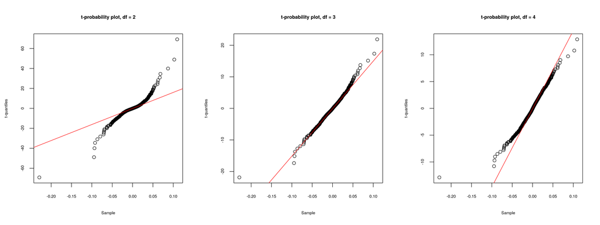

```r
par(mfrow=c(1,3))
n = dim(GSPC.rtn)[1]
grid = (1:n)/(n+1)
for (tdf in c(2, 3, 4)){
    qqplot(as.vector(GSPC.rtn), qt(grid,df=tdf),
           main= paste("t-probability plot, df =", tdf),
           xlab="Sample",ylab="t-quantiles")
    qntl = quantile(as.vector(GSPC.rtn), probs = c(0.25,0.75), na.rm=TRUE, names=FALSE)
    abline( lm( qt(c(.25,.75),df = tdf) ~ qntl ), col = 2)
}
```

- Alternatively, we may use `fitdistr()` function of `MASS` package to fit a t distribution

```r
library(MASS)
df=c(0,0,0)
retn = na.omit(GSPC.rtn)
suppressWarnings(fitdistr(retn,"t"))
```

```
        m              s              df
  5.630004e-04   6.758105e-03   2.846668e+00
 (8.499941e-05) (8.776486e-05) (9.437238e-02)
```

## 3.5 Variances are not constant

- Markets tend to go through cycles of high activity followed by low activity.
- Let us see this principle in historical data of another index, namely Dow Jones Industrial Average (symbol `^DJI`)

'^DJI'

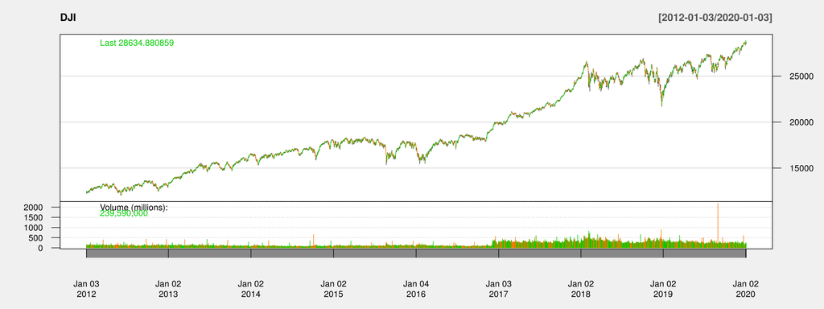

```r
getSymbols("^DJI", from="2012-01-03", src="yahoo")
chartSeries(DJI, theme="white")
```

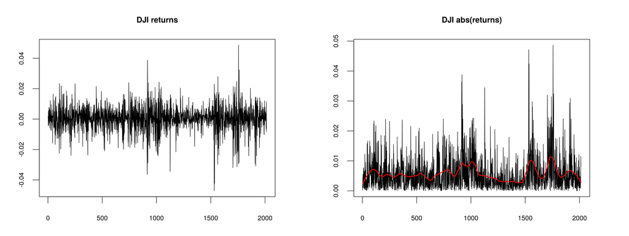

```r
rtn=coredata(na.omit(diff(log(DJI$DJI.Adjusted))))
par(mfrow=c(1,2))
par(mar=c(3,3,3,3))
plot(rtn, type="l", col=1, main = "DJI returns")
plot(abs(rtn), type="l", col=1, main = "DJI abs(returns)")
smoother = loess(abs(rtn) ~ seq(1,length(rtn)), span=0.1)
lines(seq(1,length(rtn)),fitted(smoother),col=2, lwd=2)
```